# Assignment5_part1

Prinu Mathew, Qingwei Zhang, Jake Brewer

2023-03-01

## Assignment 5 Part 1

Use the GermanCredit data (package caret) in R Cluster-wise regression

## Install packages.

```
install.packages("caret")
install.packages("tidyselect")
install.packages("ggplot2")
```

## load the package

```r
library(tidyselect)
library(caret)
```

```r
library(ggplot2)
```

## 1. Use csv or caret data.

```r
data(GermanCredit)

df <- GermanCredit
```

# 2. Use the training and Test samples for the GermanCredit data set

# that you used in Assignment 1. Call them, say, Train and Test.

```r
set.seed(3456)


# Create a function to split sample into train and test using 632:328 ratio
# # Use the same seed from the previous assignment for train-test split

split_sample_to_train_and_test <- function(df, portion = 0.632 ) {

    train_indices <- createDataPartition(df$Amount,
                                         p = portion,
                                         list = FALSE,
                                         times = 1)
    # create training set
    df_train <- df[train_indices, ]

    # create testing set
    df_test <- df[-train_indices, ]

    # view number of rows in each set
    # nrow(df_train)
    # nrow(df_test)

    # Return multiple values as list
    return(list(df_train, df_test))
}


df_split <- split_sample_to_train_and_test(df)

# check training data set
# head(df_split[[1]][])
train_set <- df_split[[1]][]

# check testing data set
# head(df_split[[2]][])
test_set <- df_split[[2]][]
```

## Load Professor’s `clustreg` and `clustreg.predict` functions

```r
clustreg=function(dat,k,tries,sed,niter)
{

    set.seed(sed)
    dat=as.data.frame(dat)
    rsq=rep(NA,niter)
    res=list()
    rsq.best=0
    for(l in 1:tries)
    {

        c = sample(1:k,nrow(dat),replace=TRUE)
        yhat=rep(NA,nrow(dat))
        for(i in 1:niter)
        {
            resid=pred=matrix(0,nrow(dat),k)
            for(j in 1:k)
            {
                pred[,j]=predict(glm(dat[c==j,],family="gaussian"),newdata=dat)
                resid[,j] = (pred[,j]-dat[,1])^2
            }

            c = apply(resid,1,which.min)
            for(m in 1:nrow(dat)) {yhat[m]=pred[m,c[m]]}
            rsq[i] = cor(dat[,1],yhat)^2
        }

        if(rsq[niter] > rsq.best)
        {
            rsq.best=rsq[niter]
            l.best=l
            c.best=c
            yhat.best=yhat
        }
    }

    res=list("Complete")
    for(i in k:1) {res=list(summary(lm(dat[c.best==i,])),res)}

    return(list(data=dat,nclust=k,tries=tries,seed=sed,rsq.best=rsq.best,number.loops=niter, Best.try=l.best,cluster=c.best,results=res))
}


clustreg.predict=function(results,newdat){

    yhat=rep(NA,nrow(newdat))
    resid=pred=matrix(0,nrow(newdat),length(table(results$cluster)))

    for(j in 1:length(table(results$cluster))){
        pred[,j]=predict(glm(results$data[results$cluster==j,],family="gaussian"),newdata=newdat)
        resid[,j] = (pred[,j]-newdat[,1])^2
    }

    c = apply(resid,1,which.min)
    for(m in 1:nrow(newdat)) {yhat[m]=pred[m,c[m]]}
    rsq = cor(newdat[,1],yhat)^2

    return(list(results=results,newdata=newdat,cluster=c,yhat=yhat,rsq=rsq))

}
```

```r
## Standardize your variables
standaridized_variables = as.data.frame(scale(train_set[,-10]))
```

## Use the Train data set to build a cluster-wise regression model.

Choose “Amount” as the dependent variable. Build 1, 2, and 3 cluster solutions. 4 clusters may be too many for this data set.

```r
train_stand <- standaridized_variables[c(2,1,3,4,5,6,7)]


# Perform cluster-wise regression for 1, 2, and 3 clusters.
# Arguments for clustreg formula are: dat, k, tries, seed, niter
clustreg.train.1=clustreg(train_stand,1,1,3456,10)
clustreg.train.2=clustreg(train_stand,2,2,3456,10)
clustreg.train.3=clustreg(train_stand,3,2,3456,10)
```

## Plot R2 as a function of the number of clusters

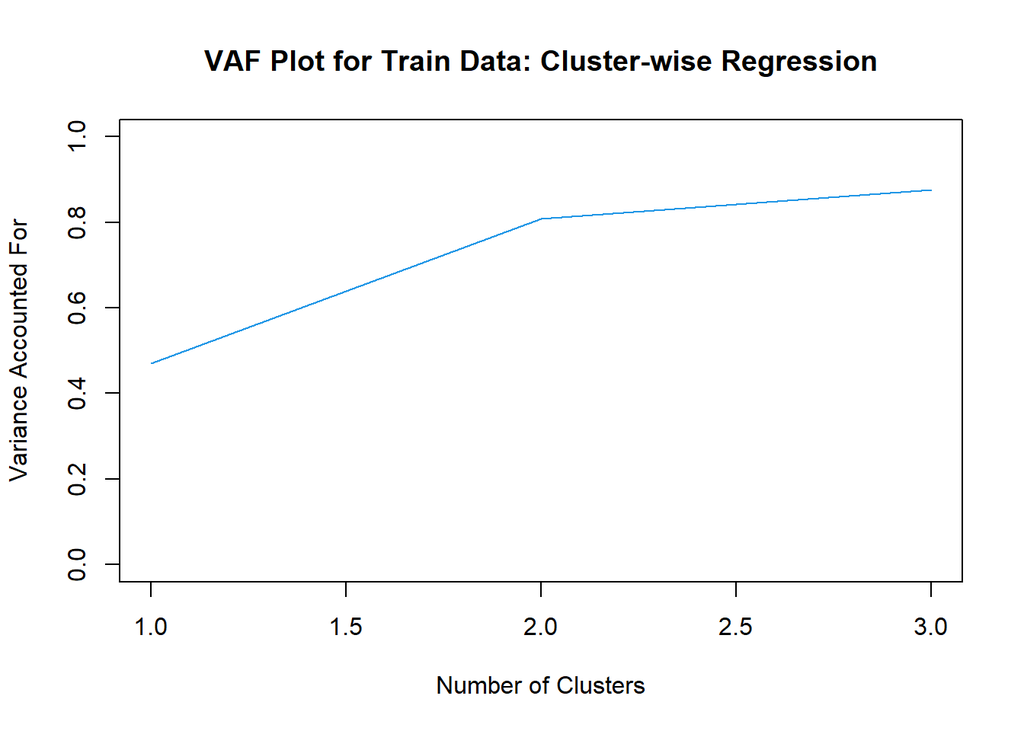

```r
# Plot R^2 as a function of the number of clusters
plot(c(1,2,3),c(clustreg.train.1$rsq.best,
                clustreg.train.2$rsq.best,
                clustreg.train.3$rsq.best),
     ylim=c(0,1),
     type="l",
     col=4,
     main="VAF Plot for Train Data: Cluster-wise Regression",
     ylab="Variance Accounted For",
     xlab="Number of Clusters")
```

## 3. Perform Test validation testing of the cluster-wise regressions using function clustreg.predict() that I have uploaded in R

```r
# Perform Test validation testing of the cluster-wise regressions
#  using function clustreg.predict().
validation_test_1 <- clustreg.predict(clustreg.train.1, test_set)

validation_test_2 <- clustreg.predict(clustreg.train.2, test_set)

validation_test_3 <- clustreg.predict(clustreg.train.3, test_set)
```

## 4. Choose the model with the best regression interpretation on

Training Data, R^2 and related significance, and the best test performance.

Show a table of training R^2, holdout R^2, and percentage decrease from train to holdout R squared: (Train R square – Holdout R square)/ Train R square. Which model is the most stable? Which performs the best on the holdout set. Which one would you choose as the final model?

```r
validation_test_1$rsq
```

```
## [1] 0.9915567
```

```r
validation_test_2$rsq
```

```
## [1] 0.9786149
```

```r
validation_test_3$rsq
```

```
## [1] 0.8011402
```

```r
# Create a table from existing data.
tab <- table(df$row_variable, df$column_variable)

tab <- matrix(nrow=3, ncol=3)
colnames(tab) <- c('Train_R2','HoldOut_R2','Percentage_decrease')
rownames(tab) <- c('K1','K2','K3')

tab[1,1] <- clustreg.train.1$rsq.best
tab[2,1] <- clustreg.train.2$rsq.best
tab[3,1] <- clustreg.train.3$rsq.best

tab[1,2] <- validation_test_1$rsq
tab[2,2] <- validation_test_2$rsq
tab[3,2] <- validation_test_3$rsq

tab[1,3] <- (clustreg.train.1$rsq.best - validation_test_1$rsq)/clustreg.train.1$rsq.best
tab[2,3] <- (clustreg.train.2$rsq.best - validation_test_2$rsq)/clustreg.train.2$rsq.best
tab[3,3] <- (clustreg.train.3$rsq.best - validation_test_3$rsq)/clustreg.train.3$rsq.best

tab
```

```
##     Train_R2 HoldOut_R2 Percentage_decrease
## K1 0.4707535  0.9915567         -1.10631835
## K2 0.8081420  0.9786149         -0.21094413
## K3 0.8764858  0.8011402          0.08596331
```

The combination for K2 seems to be the best because it has a high Train R2 and Test R2 value, whereas K1 has a very low Train R2 and K3 has a significantly lower Test R2

## Summarize your results –for both training and Test

From the training plot of R squared, which solution seems best? How did each solution perform in holdout? Are you able to interpret the results by reading the regression coefficients? Can you tell what types of clusters have been formed?

K3 is the best in the training plot. K1 did best in the holdout R squared, follow by K2 and K3.

The regression coefficients for the final model that we chose, K2, account for ~80% of the variance in the training data.

The significant coefficients in regression 1 were Duration, InstallmentRatePercentage, ResidenceDuration, Age, and Number Existing Credits Accounting for ~70% of the variance

The significant coefficients in regression 2 were Duration, InstallmentRatePercentage, and ResidenceDuration Accounting for ~70% of the variance

```r
validation_test_1$results
validation_test_2$results
validation_test_3$results
```

[output not shown]